# Regresión Lineal Multiple slides

[figure not shown]

**Econometría**  
**Profesor: Alexander Amoretti**  
**Desarrollo: Diego Armando Barquero Sánchez, Estudiante de Tercer Ciclo**

Regresión Lineal Multiple

Empleando el TAM y PIBPC como variables explicativa

Creado: 2023-May-22  
Actualizado: Sf

# Librerías Empleadas

```python
# Basics for Data Analysis
import numpy as np
import pandas as pd
# Basics for Data Visualization
import matplotlib.pyplot as plt
import seaborn as sns
%matplotlib inline
# regression basics
from scipy import stats
from sklearn.linear_model import LinearRegression
from sklearn.metrics import mean_squared_error
import statsmodels.api as sm
import statsmodels.stats.diagnostic as smd
import warnings
warnings.filterwarnings('ignore')
import statsmodels.formula.api as smf
from statsmodels.compat import lzip
import statsmodels.stats.api as sms
```

# Datos

### *Se implementa la librería pandas para cargar un set de datos*

```python
datos = pd.read_excel('datos.xlsx')
```

### *Se implementa la librería pandas para visualizar el set de datos y ver con cuales variables estaremos trabajando*

```python
datos
```

|  | MI | TAM | PIBPC |
| --- | --- | --- | --- |
| 0 | 128 | 37 | 1870 |
| 1 | 204 | 22 | 130 |
| 2 | 202 | 16 | 310 |
| 3 | 197 | 65 | 570 |
| 4 | 96 | 76 | 2050 |
| ... | ... | ... | ... |
| 59 | 115 | 62 | 1470 |
| 60 | 186 | 45 | 300 |
| 61 | 47 | 85 | 3630 |
| 62 | 178 | 45 | 220 |
| 63 | 142 | 67 | 560 |

64 rows × 3 columns

### *Como son datos transversales no se realizará un cambio en el índice del DataFrame*

### *Emplearemos la librería seaborn para visualizar los datos de "Mortalidad Infantil"*

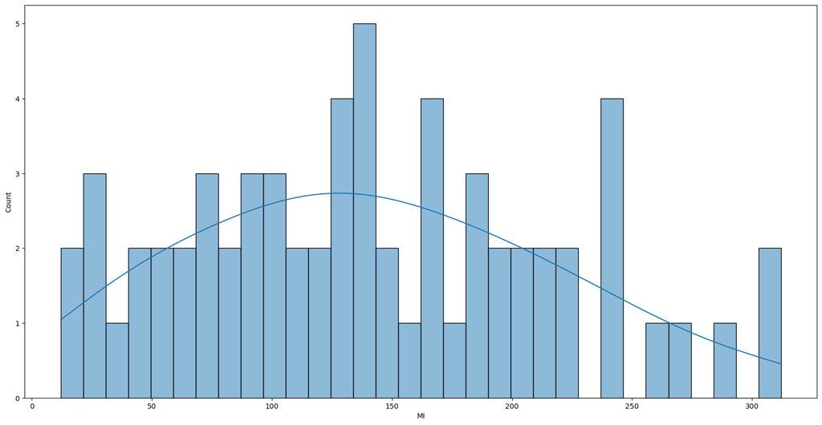

```python
plt.figure(figsize = (20,10))
sns.histplot(data=datos, x='MI', kde = True,  bins=32);
```

# Regresión Lineal Multiple

$ yi=β0+β1xi1+β2xi2+...+βpxip+ϵi $

```python
# Define la variable dependiente
y = datos['MI']

# Define la variable explicativa
x = datos[['TAM', "PIBPC"]]

# Se agrega la variable constante
x = sm.add_constant(x)

# Se realiza la regresion como tal
model = sm.OLS(y, x).fit()

# Se imprime los resultados
print(model.summary())
```

```
                            OLS Regression Results
==============================================================================
Dep. Variable:                     MI   R-squared:                       0.708
Model:                            OLS   Adj. R-squared:                  0.698
Method:                 Least Squares   F-statistic:                     73.83
Date:                Tue, 23 May 2023   Prob (F-statistic):           5.12e-17
Time:                        11:38:39   Log-Likelihood:                -328.10
No. Observations:                  64   AIC:                             662.2
Df Residuals:                      61   BIC:                             668.7
Df Model:                           2
Covariance Type:            nonrobust
==============================================================================
                 coef    std err          t      P>|t|      [0.025      0.975]
------------------------------------------------------------------------------
const        263.6416     11.593     22.741      0.000     240.460     286.824
TAM           -2.2316      0.210    -10.629      0.000      -2.651      -1.812
PIBPC         -0.0056      0.002     -2.819      0.006      -0.010      -0.002
==============================================================================
Omnibus:                        0.732   Durbin-Watson:                   2.186
Prob(Omnibus):                  0.693   Jarque-Bera (JB):                0.559
Skew:                           0.228   Prob(JB):                        0.756
Kurtosis:                       2.949   Cond. No.                     6.77e+03
==============================================================================

Notes:
[1] Standard Errors assume that the covariance matrix of the errors is correctly specified.
[2] The condition number is large, 6.77e+03. This might indicate that there are
strong multicollinearity or other numerical problems.
```

### *Como se observa en los resultados de la regresión, las variables explicativas (TAM y PIBPC) son significativas en la columna P>]t[ a un nivel de significancia de 0.05.*

# Pruebas

## -*Normalidad*-

```python
residuos = pd.DataFrame()
residuos["Ut"] = model.resid
```

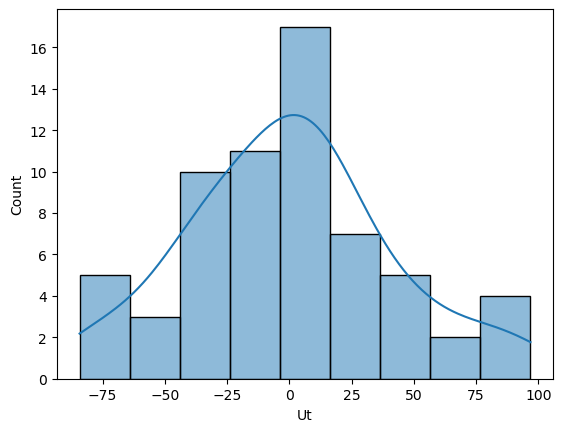

```python
sns.histplot(data = residuos, x = "Ut", kde = True);
```

```python
JB_pv = sm.stats.stattools.jarque_bera(model.resid, axis=0)[1]
print("El p-value de prueba JB es ", JB_pv)
```

```
El p-value de prueba JB es  0.7560086748021745
```

## -*Heterocedasticidad*-

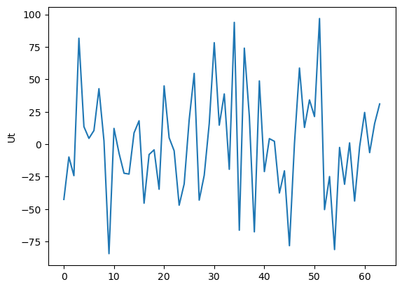

```python
sns.lineplot(data = residuos, x = residuos.index, y = "Ut");
```

```python
Nombres = ['Lagrange multiplier statistic', 'p-value',
         'f-value', 'f p-value']
BP_results = sms.het_breuschpagan(model.resid, model.model.exog)

lzip(Nombres, BP_results)
```

```
[('Lagrange multiplier statistic', 1.5915817271001416),
 ('p-value', 0.45122423697093705),
 ('f-value', 0.7778316454726383),
 ('f p-value', 0.4639035010068211)]
```

## -*Autocorrelación*-

```python
sm.stats.stattools.durbin_watson(model.resid, axis=0)
```

```
2.18615946699298
```

## -*Multicolinealidad*-

```python
def calculateVIF(var_predictoras_df):
    var_pred_labels = list(var_predictoras_df.columns)
    num_var_pred = len(var_pred_labels)

    lr_model = LinearRegression()

    result = pd.DataFrame(index = ['VIF'], columns = var_pred_labels)
    result = result.fillna(0)

    for ite in range(num_var_pred):
        x_features = var_pred_labels[:]
        y_feature = var_pred_labels[ite]
        x_features.remove(y_feature)

        x = var_predictoras_df[x_features]
        y = var_predictoras_df[y_feature]

        lr_model.fit(var_predictoras_df[x_features], var_predictoras_df[y_feature])

        result[y_feature] = 1/(1 - lr_model.score(var_predictoras_df[x_features], var_predictoras_df[y_feature]))

    return result
```

```python
calculateVIF(x)
```

|  | const | TAM | PIBPC |
| --- | --- | --- | --- |
| VIF | inf | 1.077712 | 1.077712 |

## -*Herramienta visual*-

*El código es complejo, sin embargo bastante útil debido a que en muchas ocaciones tenemos que hacer uso de funciones creadas por un desarrollador individual debido a que muchas de las funciones establecidas en otros lenguajes como r o stata en python siguen en desarrollo por parte de las grandes librerías como QuantEcon o Statsmodels*

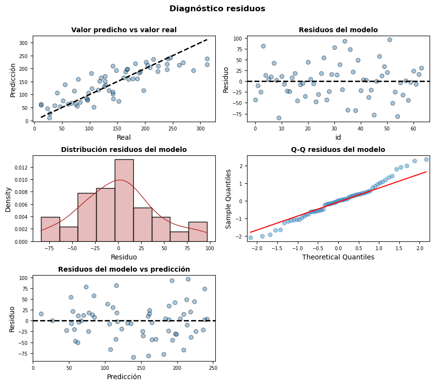

```python
# Gráficos
# ==============================================================================
fig, axes = plt.subplots(nrows=3, ncols=2, figsize=(9, 8))

axes[0, 0].scatter(y, model.fittedvalues, edgecolors=(0, 0, 0), alpha = 0.4)
axes[0, 0].plot([y.min(), y.max()], [y.min(), y.max()],
                'k--', color = 'black', lw=2)
axes[0, 0].set_title('Valor predicho vs valor real', fontsize = 10, fontweight = "bold")
axes[0, 0].set_xlabel('Real')
axes[0, 0].set_ylabel('Predicción')
axes[0, 0].tick_params(labelsize = 7)

axes[0, 1].scatter(list(range(len(y))), residuos["Ut"] ,
                   edgecolors=(0, 0, 0), alpha = 0.4)
axes[0, 1].axhline(y = 0, linestyle = '--', color = 'black', lw=2)
axes[0, 1].set_title('Residuos del modelo', fontsize = 10, fontweight = "bold")
axes[0, 1].set_xlabel('id')
axes[0, 1].set_ylabel('Residuo')
axes[0, 1].tick_params(labelsize = 7)

sns.histplot(
    data    = residuos["Ut"] ,
    stat    = "density",
    kde     = True,
    line_kws= {'linewidth': 1},
    color   = "firebrick",
    alpha   = 0.3,
    ax      = axes[1, 0]
)

axes[1, 0].set_title('Distribución residuos del modelo', fontsize = 10,
                     fontweight = "bold")
axes[1, 0].set_xlabel("Residuo")
axes[1, 0].tick_params(labelsize = 7)


sm.qqplot(
    residuos["Ut"] ,
    fit   = True,
    line  = 'q',
    ax    = axes[1, 1],
    color = 'firebrick',
    alpha = 0.4,
    lw    = 2
)
axes[1, 1].set_title('Q-Q residuos del modelo', fontsize = 10, fontweight = "bold")
axes[1, 1].tick_params(labelsize = 7)

axes[2, 0].scatter(model.fittedvalues, residuos["Ut"] ,
                   edgecolors=(0, 0, 0), alpha = 0.4)
axes[2, 0].axhline(y = 0, linestyle = '--', color = 'black', lw=2)
axes[2, 0].set_title('Residuos del modelo vs predicción', fontsize = 10, fontweight = "bold")
axes[2, 0].set_xlabel('Predicción')
axes[2, 0].set_ylabel('Residuo')
axes[2, 0].tick_params(labelsize = 7)

# Se eliminan los axes vacíos
fig.delaxes(axes[2,1])

fig.tight_layout()
plt.subplots_adjust(top=0.9)
fig.suptitle('Diagnóstico residuos', fontsize = 12, fontweight = "bold");
```

[figure not shown]

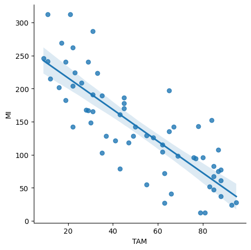

```python
sns.lmplot(data = datos, x = "TAM", y = "MI", height = 5);
```

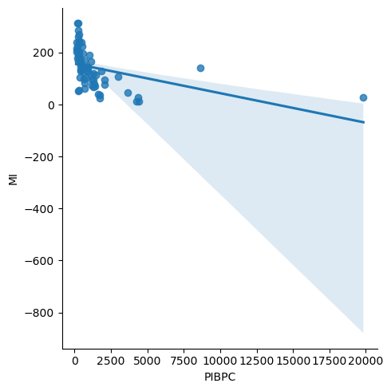

```python
sns.lmplot(data = datos, x = "PIBPC", y = "MI", height = 5);
```

# Aproximados

#### *Se puede graficar que tan cerca se encontrarón los datos estimados de los observados*

```python
datos["AproxMI"] = model.fittedvalues
```

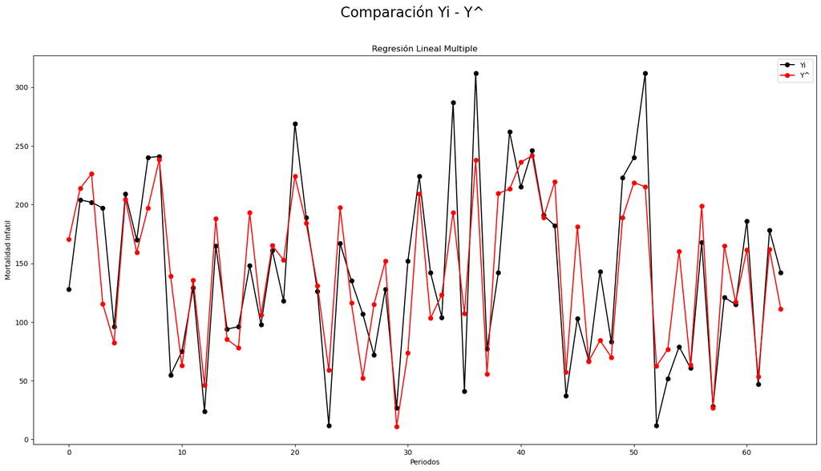

```python
fig, (ax1) = plt.subplots(1,1, figsize = (20,10))
fig.suptitle('Comparación Yi - Y^', fontsize =20)
ax1.plot(datos.index, datos['MI'], '-o',  color = 'black', label = 'Yi')
ax1.plot(datos.index, datos['AproxMI'], '-o',  color = 'red', label = 'Y^')
ax1.set(xlabel= 'Periodos', ylabel= 'Mortalidad Infatil')
ax1.set_title('Regresión Lineal Multiple')
ax1.legend(loc='best');
```

# Bibliografía y Documentación de las Librerías

##### Referencias Bibliográficas

*Carrasquilla-Batista, A., Chacon-Rodriguez, A., Núñez-Montero, K., Gómez-Espinoza, O., Valverde-Cerdas, J., & Guerrero-Barrantes, M. (2016). Regresión lineal simple y múltiple: aplicación en la predicción de variables naturales relacionadas con el crecimiento microalgal. Tecnología en Marcha. https://doi.org/10.18845/tm.v29i8.2983*

*Regresión lineal con python. (s. f.). https://www.cienciadedatos.net/documentos/py10-regresion-lineal-python.html*

*profesorDATA. (2020). Métodos de Selección de Variables: El Factor de Inflación de la Varianza. profesorDATA.com. https://profesordata.com/2020/08/22/metodos-de-seleccion-de-variables-el-factor-de-inflacion-de-la-varianza/*

*GeeksforGeeks. (2022). How to Perform a Breusch Pagan Test in Python. GeeksforGeeks. https://www.geeksforgeeks.org/how-to-perform-a-breusch-pagan-test-in-python/*

*Randall-Romero. (s. f.). EC4301/Laboratorios at master · randall-romero/EC4301. GitHub. https://github.com/randall-romero/EC4301/tree/master/Laboratorios*

##### Docuimentación Librerías

- Numpy : https://numpy.org/doc/stable/
- Pandas : https://pandas.pydata.org/docs/getting_started/index.html
- Statsmodels : https://www.statsmodels.org/devel/index.html
- Matplotlib : https://matplotlib.org/stable/gallery/index.html
- Seaborn : https://seaborn.pydata.org/
- Scikit-Learn : https://scikit-learn.org/stable/